# Homework 3

# Submission Instructions

- Please submit your responses as a nicely formatted notebook (.ipynb) file.
- For questions that require calculations:
  - Show your work (i.e., show the R code you used to answer the question).
  - Make sure all the code you used to answer the question has been run (i.e., displays an output) otherwise you will get a zero for that question.
  - If your *answer* includes many decimal places (e.g., 3.14159265358979), please round it to a reasonable number of decimals for readability (typically 3 to 4).
  - There should be no rounding inside the calculations you do, only round the final result if necessary.
  - For ease of marking, avoid showing the outputs of unnecessary values (short meaningful comments `#` in your code are fine).
  - **If a function or package is prohibited, so are other functions and packages that perform equivalent calculations.**
  - Unless specified otherwise, assume $\alpha = 0.05$.

# Question 1

Some archaeologists theorize that ancient Egyptians interbred with several different immigrant populations over thousands of years. To see if there is any indication of changes in body structure that might have resulted, they measured 30 skulls of male Egyptians dated from 4000 B.C.E. and 30 others dated from 200 B.C.E. We will be using this data to conduct a classic independent t-test to compare the means of the two epochs.

- Thomson and Randall-Maciver, *Ancient Races of the Thebaid*, Oxford: Oxford University Press, 1905.

The data can be found in **“SkullsPartial.csv”**. The column “mb” measures the maximal breadth of the skull.

The data is in the “tidy format”. Find a way to calculate the means for both epochs, as well as the difference between the means. *No special packages are required for this*. You have already learned methods which can help you here.

> *There are a bunch of basic ways to do this with tidy formatted data, here are a few simple methods. The second and third methods are the most preferable in this instance because they work even if the data is out of order.*

```r
library(tidyverse)
skulls <- read_csv("../Data/SkullsPartial.csv")

# METHOD 1.
# You can index the values you need specifically.
# Note: if the data is not in a logical order (i.e., if it is shuffled) this method doesn't work.

m_4000 <- mean(skulls$mb[1:30])
m_200 <- mean(skulls$mb[31:60])
m_diff <- m_4000 - m_200
```

```
## m_4000 = 131.367
```

```
## m_200 = 135.5
```

```
## m_diff = -4.133
```

```r
# METHOD 2.
# You can use the filter function and pull out the column you want as a vector.

m_4000 <- mean(filter(skulls, epoch == "c4000BC")$mb)
m_200 <- mean(filter(skulls, epoch == "c200BC")$mb)
m_diff <- m_4000 - m_200
```

```
## m_4000 = 131.367
```

```
## m_200 = 135.5
```

```
## m_diff = -4.133
```

```r
# METHOD 3.
# You can use a logical statement inside your index to subset according to the grouping column "epoch".

m_4000 <- mean(skulls$mb[skulls$epoch == "c4000BC"])
m_200 <- mean(skulls$mb[skulls$epoch == "c200BC"])
m_diff <- m_4000 - m_200
```

```
## [1] "m_4000 =  131.367"
```

```
## [1] "m_200 = 135.5"
```

```
## [1] "m_diff = -4.133"
```

> Note: depending on how you subtract the group means, the mean difference will be either negative or positive.

# Question 2

Using the skull data, calculate the standard deviation and variance for both epochs.

```r
# Standard Deviation
s_4000 <- sd(skulls$mb[skulls$epoch == "c4000BC"])
s_200 <- sd(skulls$mb[skulls$epoch == "c200BC"])

# Variance
var_4000 = s_4000^2
var_200 <- s_200^2
```

```
## [1] "s_4000 =  5.129"
```

```
## [1] "var_4000 =  26.309"
```

```
## [1] "s_200 =  3.919"
```

```
## [1] "var_200 =  15.362"
```

# Question 3

Using the skull data, calculate the pooled variance.

```r
# Group Sample Size
n_4000 <- length(skulls$mb[skulls$epoch == "c4000BC"])
n_200 <- length(skulls$mb[skulls$epoch == "c200BC"])

# Pooled Variance
sp_sq <- ((n_4000 - 1)*var_4000 + (n_200 - 1)*var_200) / (n_4000 + n_200 - 2)
sp_sq
```

```
## [1] 20.83563
```

# Question 4

Using the skull data, calculate the pooled standard error.

```r
se <- sqrt(sp_sq / n_4000 + sp_sq / n_200)
se
```

```
## [1] 1.178576
```

# Question 5

Calculate a two-sided 95% confidence interval for the difference in mean skull breadth between these two epochs. Use of `t.test()` is not permitted.

```r
df <- n_4000 + n_200 - 2
alpha <- 0.05
t_crit <- abs(qt(alpha/2, df = df))

lower <- m_diff - t_crit * se
upper <- m_diff + t_crit * se
```

```
## [-6.493, -1.774]
```

> Note: depending on how you subtracted the means, this confidence interval will either be entirely negative or entirely positive with the values flipped.

# Question 6

Test $H_0: \mu_{_\text{4000}} - \mu_{_\text{200}} = 0$.

Use of `t.test()` is not permitted.

Make sure to report:

- the test statistic
- p-value
- whether your reject or fail to reject the $H_0$

```r
mu <- 0
t <- (m_diff - mu) / se

# Since the test statistic is negative in this case (i.e., below 0),
  # we calculate the p-value from left to right.
p <- pt(t, df = df) * 2
```

```
## Test statistic: -3.507
```

```
## p = 0.001
```

```
## Since p < .05 we reject the null hypothesis.
```

> Note: depending on how you subtracted the means, the test statistic will be either postive or negative. This will impact the direction you need calculate your p-value.

# Question 7

A researcher states their null hypothesis about the skull data as $H_0: \mu_{_\text{4000}} < \mu_{_\text{200}}$.

Another way of expressing this is by writing: $H_0: \mu_{_\text{4000}} - \mu_{_\text{200}} < 0$.

Given the null hypothesis being expressed, answer the following questions:

## a.

Is this a one or two-tailed hypothesis?

- One-tailed

## b.

How would you interpret this hypothesis in plain English?

- The breadth of 4000 B.C.E. skulls are smaller (on average) than 200 B.C.E. skulls.

## c.

In which tail is the critical region located for this hypothesis’ test statistic?

- Right tail.
  - *Rationale for those interested:* Since the null hypothesis states that the difference between 4000BCE and 200BCE will be anything LESS than 0, you need to find a mean difference greater than 0 to falsify the claim.

## d.

Given what you said in “c.”, which direction should a p-value be calculated? From $-\infty$ upward OR from $+\infty$ downward?

- $+\infty$ downward.

## e.

There are two other mathematically equivalent ways of writing the null hypothesis here. What are they? Your answer should take the form of “$H_0:$________”.

- $H_0: \mu_{_\text{200}} - \mu_{_\text{4000}} > 0$
- $H_0: \mu_{_\text{200}} > \mu_{_\text{4000}}$

# Question 8

Test $H_0: \mu_{_\text{4000}} - \mu_{_\text{200}} < 0$ or an equivalent version of it. Report the p-value and 95% confidence interval, and state whether you reject the null hypothesis. Use of `t.test()` is not permitted.

```r
# P-value
p <- pt(t, df = df, lower.tail = FALSE)
p
```

```
## [1] 0.999559
```

```r
# Critical t
alpha = 0.05
t_crit <- abs(qt(alpha, df = df))

# 95% CI
low_ci <- m_diff - t_crit * se
top_ci <- m_diff + Inf * se

paste0("95% CI = [", round(low_ci, 4), ", ", top_ci, ")")
```

```
## [1] "95% CI = [-6.1034, Inf)"
```

> Since p > 0.05 and/or 0 is contained in the confidence interval, we FAIL to reject the null hypothesis. i.e., we can’t reject the claim that the 4000 B.C.E skulls are smaller on average.
- Note: if you subtracted the means in the opposite direction (e.g. $\mu_{_\text{200}} - \mu_{_\text{4000}}$) then your null hypothesis becomes $H_0: \mu_{_\text{200}} - \mu_{_\text{4000}} > 0$. Stated this way, the critical region is in the left tail and the p-value needs to be calculated from left to right. The confidence interval would also flip (Inf, 6.1034].

# Question 9

Create a barplot of the means for the Skull data. Give each bar two-sided 95% confidence intervals as the errorbars. Have the y-axis go from 110 to 140.

- *Note: to solve this I am using the “manual” way of plotting. You could use ggplot’s automated functions as well.*

```r
plot_data <- skulls |>
  group_by(epoch) |>
  summarise(
    n = length(mb),
    m = mean(mb),
    df = n - 1,
    alpha = 0.05,
    t_crit = abs(qt(alpha / 2, df = df)),
    se = sd(mb) / sqrt(n),
    moe = t_crit * se
  )

plot_data # Note: you do not need to display this information, just providing it for reference.
```

```
## # A tibble: 2 × 8
##   epoch       n        m    df alpha   t_crit        se      moe
##   <chr>   <int>    <dbl> <dbl> <dbl>    <dbl>     <dbl>    <dbl>
## 1 c200BC     30 135.5       29  0.05 2.045230 0.7155899 1.463546
## 2 c4000BC    30 131.3667    29  0.05 2.045230 0.9364685 1.915293
```

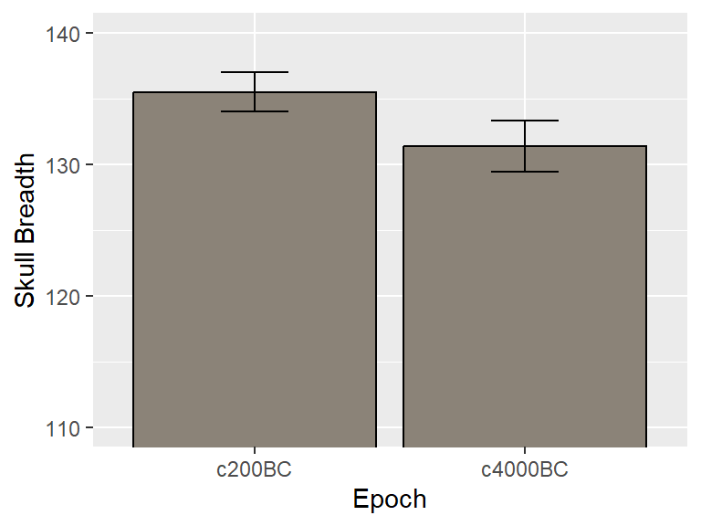

```r
ggplot(plot_data, aes(x = epoch, y = m)) +
  geom_bar(
    stat = "identity",
    fill = "antiquewhite4",
    colour = "black"
  ) +
  geom_errorbar(
    aes(ymin = m - moe, ymax = m + moe),
    width = 0.25
  ) +
  coord_cartesian(ylim = c(110, 140)) +
  xlab("Epoch") +
  ylab("Skull Breadth")
```

# Question 10

Suppose that the summary stats of your groundbreaking research are . . .

$\bar{x}_1 = 15$

$\bar{x}_2 = 12$

$s^2_1 = 8$

$s^2_2 = 24$

$n_1 = 20$

$n_2 = 10$

Verify that $s^2_p = 13.14$, $T = 2.14$ when rounded to two decimals, and that a classic T-test rejects the null hypothesis of equal means with $\alpha = 0.05$. Compute a confidence interval for this hypothesis test.

```r
m1 <- 15
m2 <- 12
var1 <- 8
var2 <- 24
n1 <- 20
n2 <- 10
alpha <- 0.05

# CALCULATIONS

# Pooled Variance
var_pool <- ((n1 - 1) * var1 + (n2 - 1) * var2) / (n1 + n2 - 2)

# Standard Error (of the Difference between groups)
se_diff <- sqrt((var_pool / n1) + (var_pool / n2))

# Test Statistic
t_stat <- ((m1 - m2) - 0) / se_diff

# Dregrees of Freedom
df <- n1 + n2 - 2

# P-Value
p <- pt(t_stat, df = df, lower.tail = FALSE) * 2

# Critical T
t_crit <- abs(qt(alpha / 2, df = df))

# Confidence Interval
bottom <- (m1 - m2) - t_crit * se_diff
top <- (m1 - m2) + t_crit * se_diff
ci <- paste0("95% CI [", round(bottom, 3), ", ", round(top, 3), "]")
```

```r
# Pooled Variance
round(var_pool, 2)
```

```
## [1] 13.14
```

```r
# Test Statistic
round(t_stat, 2)
```

```
## [1] 2.14
```

```r
# P-Value
round(p, 3)
```

```
## [1] 0.042
```

```r
# Confidence Interval
ci
```

```
## [1] "95% CI [0.124, 5.876]"
```

The pooled variance and the test statistic are both correct and the classic t-test rejects the hypothesis of equal means.

# Question 11

Using the information from the previous question, plot the group means and their respective two-sided confidence intervals. Label the two groups A and B. The plot you create should match the plot below. FYI: The colour used is `"aquamarine4"`.

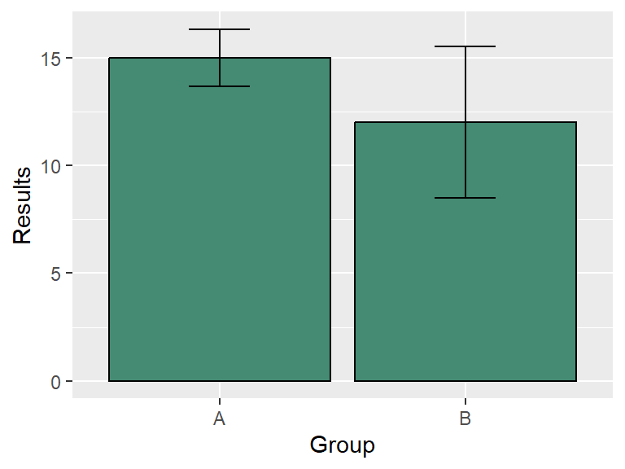

- Hint: To complete this task, you will need to create a data frame containing the relevant values. Since we do not have access to the original dataset, you cannot rely on ggplot’s automated methods or the `summarise()` function to generate the necessary summaries. Instead, you must manually construct a data frame that contains the aggregated values needed for ggplot. This process is actually simpler than it might seem—think back to our early lectures on working with data frames in R.

```r
# Getting values for the plot's data frame
group <- c("A", "B")
results <- c(m1, m2)
n <- c(n1, n2)
df <- n - 1
sd <- c(sqrt(var1), sqrt(var2))
se <- sd / sqrt(n)
alpha <- 0.05
t_crit <- abs(qt(alpha / 2, df = df))
moe <- se * t_crit
lower_ci <- results - moe
upper_ci <- results + moe

# Placing the important values in a data frame.
plot_data <- data.frame(group, results, moe, lower_ci, upper_ci)
plot_data
```

```
##   group results      moe  lower_ci upper_ci
## 1     A      15 1.323745 13.676255 16.32374
## 2     B      12 3.504519  8.495481 15.50452
```

```r
# Note it is not necessary to print the data frame.  I just did it to show you the values I got.
```

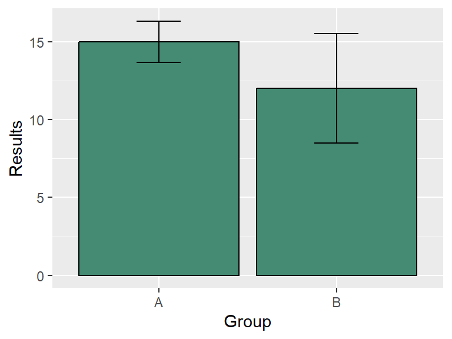

```r
ggplot(plot_data, aes(x = group, y = results)) +
  geom_bar(
    stat = "identity",
    colour = "black",
    fill = "aquamarine4"
  ) +
  geom_errorbar(
    aes(ymin = lower_ci, ymax = upper_ci),
    width = 0.25
  ) +
  xlab("Group") +
  ylab('Results')
```

# Question 12

What is a potentially serious problem for the results seen in the previous question (hint: compare the errorbars)?

> The spread are quite different meaning that the homogeneity of variance assumption might be violated.

# Question 13

Conduct a test that is designed to solve the *specific* problem noted by the previous question. Do the conclusions change from what you got when you ran a classic t-test? Specify the name of the test you ran, its test statistic, degrees of freedom, p-value, and two-sided 95% confidence interval.

```r
m1 <- 15
m2 <- 12
var1 <- 8
var2 <- 24
n1 <- 20
n2 <- 10
alpha <- 0.05

# CALCULATIONS FOR WELCH T-TEST

# Degrees of Freedom
q1 <- var1 / n1
q2 <- var2 / n2

df <- ((q1 + q2)^2) / ((q1^2) / (n1 - 1) + (q2^2) / (n2 - 1))

# Standard Error of the Difference (i.e., Test Stat denominator)
se_diff <- sqrt(q1 + q2)

# Test Statistic
t_stat <- ((m1 - m2) - 0) / se_diff

# Critical T
t_crit <- abs(qt(.025, df = df))

# P-value
p <- pt(t_stat, df = df, lower.tail = FALSE) * 2

# Confidence Interval
bottom <- (m1 - m2) - t_crit * se_diff
top <- (m1 - m2) + t_crit * se_diff
```

```
## Test statistic: 1.793
```

```
## df = 12.091
```

```
## p = 0.098
```

```
## 95% CI [-0.643, 6.643]
```

> Using a Welch T-test, $p > .05$ and we therefore FAIL to reject $H_0$. Yes, the results change. Using the classic test, which assumed equal variances, we had rejected the null hypothesis.

# Question 14

Responses to stress are governed, in part, by the hypothalamus. Imagine you have two groups of participants. The first shows signs of heart disease and the other does not. You want to determine whether the groups differ (in any direction) in terms of the weight of the hypothalamus.

Use the data “**heartDisease.csv**” to determine whether the groups differ based on a classic t-test. Use $\alpha = .05$. Use of `t.test()` is not permitted.

Make sure to report:

- the test statistic
- degrees of freedom
- p-value
- Confidence Interval
- Whether your reject or fail to reject the $H_0$

```r
# Data
hearts <- read_csv("../Data/heartDisease.csv")

# Get Summary Statistic Information:
  # Note I am using the summarise() function collect the group statistics I need.
  # e.g., the means, variances, sample sizes , etc.

# There are other ways you could do this, this is just convenient to stay
  # organized and makes the code more elegant when we have nasty equations
  # like the pooled variance and standard error.

stats <- hearts |>
  group_by(disease) |>
  summarise(
    n = length(hypoWeight),
    m = mean(hypoWeight),
    v = var(hypoWeight)
  )

stats
```

```
## # A tibble: 2 × 4
##   disease     n        m        v
##   <chr>   <int>    <dbl>    <dbl>
## 1 No         11 12.06364 14.58455
## 2 Yes        15 15.66667 31.08381
```

```r
# Pooled variance
v_p <- sum((stats$n - 1) * stats$v) / sum(stats$n - 1)

# Pooled Standard Error of the Difference
se <- sqrt(sum(v_p / stats$n))

# Test Statistic
mu_diff <- 0
t <- ((stats$m[1] - stats$m[2]) - mu_diff) / se

# Degrees of Freedom
df <- sum(stats$n) - 2

# p-value
p <- pt(t, df = df) * 2

# 95% Confidence Interval
alpha <- 0.05
t_crit <- qt(alpha / 2, df = df, lower.tail = FALSE)

lower <- (stats$m[1] - stats$m[2]) - t_crit * se
upper <- (stats$m[1] - stats$m[2]) + t_crit * se
```

```
## Test statistic: -1.845
```

```
## df = 24
```

```
## p = 0.077
```

```
## 95% CI [-7.634, 0.428]
```

> Since $p > .05$ we FAIL to reject. There is no significant difference in hypothalamus weight between individuals with and without heart disease.

Note: By having the basic values stored in a data frame, I was able to utilize R’s ability to work with vectors. This allowed me to write code more efficiently. For instance, many people would have written pooled variance something like this:

- `v_p <- ((stats$n[1] - 1) * stats$v[1] + (stats$n[2] - 1) * stats$v[2]) / (stats$n[1] + stats$n[2] - 2)`

That is long and gross. We can simplify with the `sum()` function:

- `v_p <- sum((stats$n - 1) * stats$v) / sum(stats$n - 1)`

# Question 15

Compute an appropriate measure of effect size for the previous question. Use of `cohen.d()` is not permitted.

```r
d <- (stats$m[1] - stats$m[2]) / sqrt(v_p)
g <- d * (1 - 3/(4 * sum(stats$n) - 9))
```

```
## g = -0.709
```

Note: due to the small sample size, Hedge’s g needs to be calculated.

# Question 16

Repeat question 14, but use a Welch’s t-test. Use of `t.test()` is not permitted.

```r
stats <- hearts |>
  group_by(disease) |>
  summarise(
    n = length(hypoWeight),
    m = mean(hypoWeight),
    v = var(hypoWeight),
    q = v / n
  )

stats
```

```
## # A tibble: 2 × 5
##   disease     n        m        v        q
##   <chr>   <int>    <dbl>    <dbl>    <dbl>
## 1 No         11 12.06364 14.58455 1.325868
## 2 Yes        15 15.66667 31.08381 2.072254
```

```r
# Degrees of Freedom
df <- (sum(stats$q)^2) / sum((stats$q^2)  / (stats$n - 1))

# Standard Error (of the difference)
se <- sqrt(sum(stats$q))

# Test Statistic
t <- ((stats$m[1] - stats$m[2]) - 0) / se

# P-value
p <- pt(t, df = df) * 2

# Critical T
alpha <- 0.05
t_crit <- abs(qt(alpha / 2, df = df))

# Confidence Interval
lower <- (stats$m[1] - stats$m[2]) - t_crit * se
upper <- (stats$m[1] - stats$m[2]) + t_crit * se
```

```
## Test statistic: -1.955
```

```
## df = 23.931
```

```
## p = 0.062
```

```
## 95% CI [-7.408, 0.202]
```

> Since $p > .05$ we FAIL to reject. There is no significant difference in hypothalamus weight between individuals with and without heart disease.

# Question 17

Plot the group means with their respective two-sided confidence intervals for the **heartDisease.csv** data.

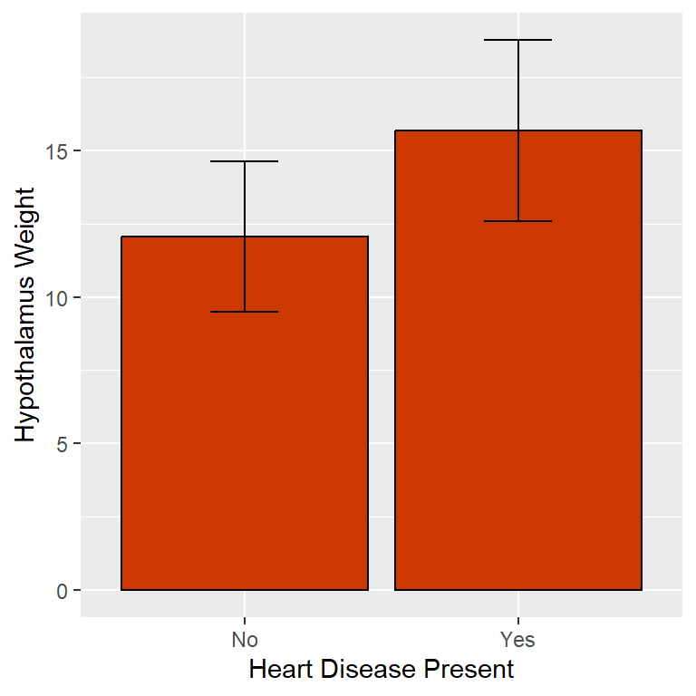

```r
plot_data <- hearts |>
  group_by(disease) |>
  summarise(
    n = length(hypoWeight),
    mean = mean(hypoWeight),
    s = sd(hypoWeight),
    se = s / sqrt(n),
    df = n - 1,
    alpha = 0.05,
    t_crit = abs(qt(alpha / 2, df = df)),
    moe = t_crit * se
  )

ggplot(plot_data, aes(x = disease, y = mean)) +
  geom_bar(
    stat = "identity",
    colour = "black",
    fill = "orangered3"
    ) +
  geom_errorbar(
    aes(ymin = mean - moe, ymax = mean + moe),
    width = .25
  ) +
  xlab("Heart Disease Present") +
  ylab("Hypothalamus Weight")
```

# Question 18

Repeat question 14 using 20% Trimmed Means. Do you get a different conclusion? Use of `yuen()` is not permitted.

```r
library(WRS2)

# Get Summary Statistic Information:
# This process is simplified greatly using the summarise() function
stats <- hearts |>
  group_by(disease) |>
  summarise(
    n = length(hypoWeight),
    G = .2,
    m = mean(hypoWeight, tr = G),
    v = winvar(hypoWeight, tr = G),
    h = n - 2 * floor(G * n),
    d = ((n - 1) * v) / (h * (h - 1))
  )

stats
```

```
## # A tibble: 2 × 7
##   disease     n     G        m        v     h         d
##   <chr>   <int> <dbl>    <dbl>    <dbl> <dbl>     <dbl>
## 1 No         11   0.2 11.85714 7.043636     7 1.677056
## 2 Yes        15   0.2 14.03333 2.838571     9 0.5519444
```

```r
# Standard Error of the Difference Between ms
se <- sqrt(sum(stats$d))

# Test Statistic
t <- ((stats$m[1] - stats$m[2]) - 0) / se

# Degrees of Freedom
df <- (sum(stats$d)^2) / sum((stats$d^2) / (stats$h - 1))

# P-value
p <- pt(t, df = df) * 2

# Critical T
alpha <- 0.05
t_crit <- abs(qt(alpha / 2, df = df))

# Confidence Interval
lower <- (stats$m[1] - stats$m[2]) - t_crit * se
upper <- (stats$m[1] - stats$m[2]) + t_crit * se
```

```
## Test statistic: -1.458
```

```
## df = 9.803
```

```
## p = 0.176
```

```
## 95% CI [-5.512, 1.159]
```

```
## Since p > .05 we FAIL to reject. The conclusion is still the same.
```

# Question 19

Using the **heartDisease.csv** data set, create a plot showing the 20% trimmed mean for each group, along with their corresponding two-sided confidence intervals.

```r
plot_data <- hearts |>
  group_by(disease) |>
  summarise(
    n = length(hypoWeight),
    G = .2,
    mean = mean(hypoWeight, tr = G),
    var = winvar(hypoWeight, tr = G),
    s = sqrt(var),
    se = s / ((1 - 2 * G) * sqrt(n)),
    h = n - 2 * floor(G * n),
    df = h - 1,
    alpha = 0.05,
    t_crit = qt(alpha / 2, df = df, lower.tail = FALSE),
    moe = se * t_crit
  )

plot_data
```

```
## # A tibble: 2 × 12
##   disease     n     G     mean      var        s        se     h    df alpha
##   <chr>   <int> <dbl>    <dbl>    <dbl>    <dbl>     <dbl> <dbl> <dbl> <dbl>
## 1 No         11   0.2 11.85714 7.043636 2.653985 1.333678      7     6  0.05
## 2 Yes        15   0.2 14.03333 2.838571 1.684806 0.7250251     9     8  0.05
##     t_crit      moe
##      <dbl>    <dbl>
## 1 2.446912 3.263392
## 2 2.306004 1.671911
```

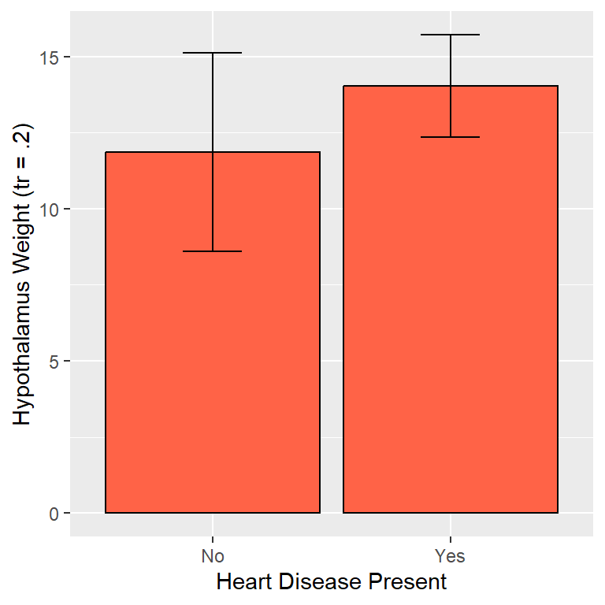

```r
ggplot(plot_data, aes(x = disease, y = mean)) +
  geom_bar(
    stat = "identity",
    colour = "black",
    fill = "tomato1"
    ) +
  geom_errorbar(
    aes(ymin = mean - moe, ymax = mean + moe),
    width = .25
  ) +
  xlab("Heart Disease Present") +
  ylab("Hypothalamus Weight (tr = .2)")
```

# Question 20

Generate Q-Q plots to assess the normality assumption of the **heartDisease.csv** data. Should a classic t-test be run on this data?

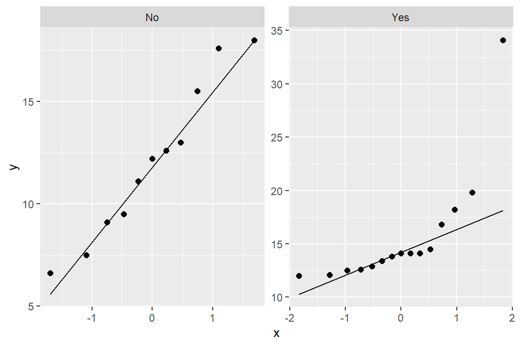

```r
ggplot(hearts, aes(sample = hypoWeight)) +
  stat_qq(size = 2) +
  stat_qq_line() +
  facet_wrap(~ disease, scales = "free")
```

> The “yes” group’s data (i.e., the group with signs of heart disease) waivers alot (i.e., does not form a straight line). Consequently, the assumption that both groups belong to normally distributed populations is likely violated. A classical t-test should therefore NOT be run on this data.

> > Note: for full marks you need to display a seperate q-q plot for each group because the groups are independent.

# Question 21

Generate boxplots to compare the two groups of the **heartDisease.csv** data. Make the boxplots pretty colours.

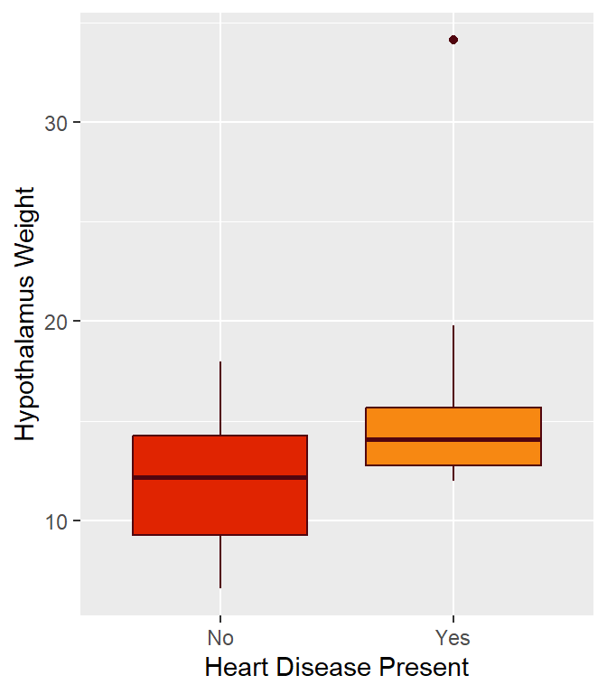

```r
ggplot(hearts, aes(x = disease, y = hypoWeight)) +
  geom_boxplot(
    aes(fill = disease),
    colour = "#51050F"
    ) +
  scale_fill_manual(values = c("#E02401", "#F78812")) +
  xlab("Heart Disease Present") +
  ylab("Hypothalamus Weight") +
  theme(legend.position = "none")
```

# Question 22

To investigate the question “*do sexual images in advertisements affect people’s ability to remember the item being advertised*”, a group of statistics students cut ads out of magazines. They were careful to find two ads for each of 10 similar items, one with a sexual image and one without. They arranged the ads in a random order and had 39 subjects look at them for 1 minute. They then asked the subjects to list as many of the products as they could remember. Their data can be found in the file **sexSells.csv**.

Notice that the data is in the tidy format but it is not in a logical order. This is a common problem with data sets. Find a way to *order* the data by the ‘Image’ and ‘Subject’ columns (below is an example of the first 10 rows ordered appropriately). Display the ordered dataset’s full output.

Hint: no special packages are required for this and a basic internet search should give you the solution you desire.

```
## # A tibble: 10 × 3
##    Subject AdRecall Image
##      <dbl>    <dbl> <chr>
##  1       1        2 NotSexy
##  2       2        7 NotSexy
##  3       3        1 NotSexy
##  4       4        5 NotSexy
##  5       5        0 NotSexy
##  6       6        3 NotSexy
##  7       7        5 NotSexy
##  8       8        4 NotSexy
##  9       9        7 NotSexy
## 10      10        4 NotSexy
```

Using Base-R functions…

```r
# Load Disorganized Data
ad_data <- read_csv("../Data/sexSells.csv")

# Use the 'order' function inside your row index
ad_data <- ad_data[order(ad_data$Image, ad_data$Subject), ]

ad_data
```

```
## # A tibble: 78 × 3
##    Subject AdRecall Image
##      <dbl>    <dbl> <chr>
##  1       1        2 NotSexy
##  2       2        7 NotSexy
##  3       3        1 NotSexy
##  4       4        5 NotSexy
##  5       5        0 NotSexy
##  6       6        3 NotSexy
##  7       7        5 NotSexy
##  8       8        4 NotSexy
##  9       9        7 NotSexy
## 10      10        4 NotSexy
## 11      11        3 NotSexy
## 12      12        2 NotSexy
```

[output cut: 66 more lines]

If you want to stay in the tidyverse …

```r
# Pipe the data into the arrange() function
ad_data <- read_csv("../Data/sexSells.csv") |>
  arrange(Image, Subject)

ad_data
```

```
## # A tibble: 78 × 3
##    Subject AdRecall Image
##      <dbl>    <dbl> <chr>
##  1       1        2 NotSexy
##  2       2        7 NotSexy
##  3       3        1 NotSexy
##  4       4        5 NotSexy
##  5       5        0 NotSexy
##  6       6        3 NotSexy
##  7       7        5 NotSexy
##  8       8        4 NotSexy
##  9       9        7 NotSexy
## 10      10        4 NotSexy
## 11      11        3 NotSexy
## 12      12        2 NotSexy
```

[output cut: 66 more lines]

# Question 23

Using $\alpha = 0.05$, assume the data come from a normally distributed population and test the hypothesis that sexual ads are remembered **better** than the nonsexual ads. i.e., $H_0: \mu_{\text{sexy}} - \mu_{\text{notSexy}} > 0$. Use of `t.test()` is not permitted.

Make sure to report:

- the test statistic
- the degrees of freedom
- p-value
- Confidence Interval
- Whether you reject or fail to reject $H_0$

```r
#Calculate Difference Scores
diff_scores <- ad_data$AdRecall[ad_data$Image == "Sexy"] -
  ad_data$AdRecall[ad_data$Image == "NotSexy"]

#Summary Stats
N <- length(diff_scores)
m <- mean(diff_scores)
mu <- 0
se <- sd(diff_scores)/sqrt(N)

#Test Statistic
t <- (m - mu)/se

# Degrees of Freedom
df <- N - 1

# p-val
#H0: sexy > nonSexy
# i.e., sexy - nonSexy > 0
p <- pt(t, df = df)

# Confidence interval
alpha <- 0.05
t_crit <- abs(qt(alpha, df = df))

low_ci <- m - Inf * se
top_ci <- m + t_crit * se
```

```
## T = 0.859
```

```
## df = 38
```

```
## p = 0.802
```

```
## [1] "95% CI = (-Inf, 0.6836]"
```

> We FAIL to reject the null hypothesis that $H_0: \mu_{\text{sexy}} - \mu_{\text{notSexy}} > 0$.

# Question 24

Calculate an appropriate effect size for question 23. What is this effect size telling us? Use of `cohen.d()` is not permitted.

```r
# Correlation
R <- cor(
  ad_data$AdRecall[ad_data$Image == "Sexy"],
  ad_data$AdRecall[ad_data$Image == "NotSexy"]
) # Note that the data needs to be in a logical order for this to give the correct result.

s_rm <- sd(diff_scores) / sqrt(2*(1 - R))

d <- mean(diff_scores) / s_rm

# Check number of pairs
length(ad_data$AdRecall[ad_data$Image == "Sexy"])
```

```
## [1] 39
```

```r
#Since there are less than 50 pairs, we will use Hedge's g.
g <- d * (1 - (3 / (4*(df)-1)))
g
```

```
## [1] 0.1314418
```

> The difference in recall between the two types of ads is small, amounting to approximately 0.131 standard deviations.

# Question 25

What are the independent and dependent variables in the **sexSells.csv** study?

- *Dependent Variable:* Ad recall
- *Independent Variable:* Image in the ad (i.e., Sexy vs. Not Sexy)

# Question 26

Plot a bar graph showing the means of both groups and their difference. Give each bar an errorbar that corresponds to a two-sided 95% confidence interval around the mean.

```r
#Add difference scores to the dataframe
diff_data <- data.frame(
  Subject = 1:39,
  AdRecall = diff_scores,
  Image = c(rep("Difference", 39))
)

ad_data_diff <- rbind(ad_data, diff_data)
```

```r
# Obtain values for plot
plot_data <- ad_data_diff %>%
  group_by(Image) %>%
  summarise(
    n = length(AdRecall),
    m = mean(AdRecall),
    se = sd(AdRecall) / sqrt(n),
    df = n - 1,
    alpha = 0.05,
    t_crit = abs(qt(alpha / 2, df)),
    moe = se * t_crit,
    lower = m - t_crit,
    upper = m + t_crit
  )
```

```r
# Factoring data to put bars in a sensible order
plot_data$Image <- factor(plot_data$Image,
  levels = c("Sexy", "NotSexy", "Difference")
)
```

```r
# For reference, here are the plotting values
plot_data
```

```
## # A tibble: 3 × 10
##   Image          n         m        se    df alpha   t_crit       moe     lower
##   <fct>      <int>     <dbl>     <dbl> <dbl> <dbl>    <dbl>     <dbl>     <dbl>
## 1 Difference    39 0.2307692 0.2686035    38  0.05 2.024394 0.5437593 -1.793625
## 2 NotSexy       39 3.538462  0.2670531    38  0.05 2.024394 0.5406207  1.514067
## 3 Sexy          39 3.769231  0.2832755    38  0.05 2.024394 0.5734612  1.744837
##      upper
##      <dbl>
## 1 2.255163
## 2 5.562856
## 3 5.793625
```

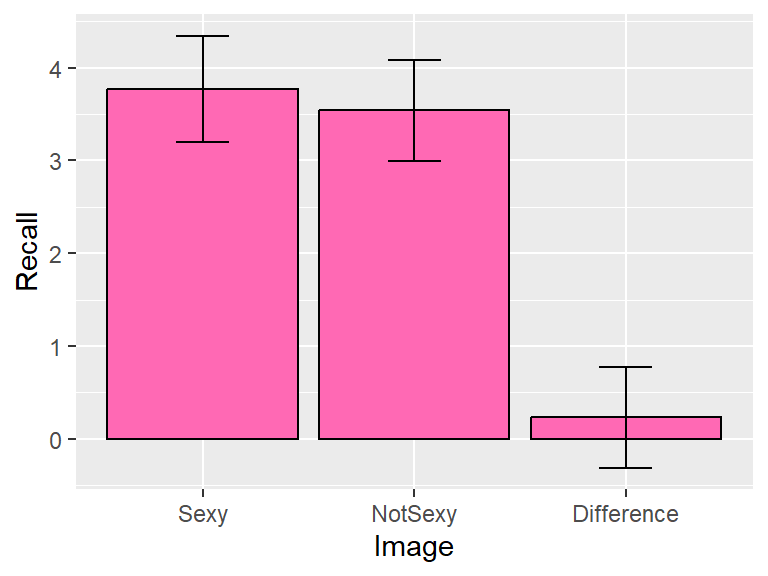

```r
# Plot the Data
ggplot(plot_data, aes(x = Image, y = m)) +
  geom_bar(
    stat = "identity",
    colour = "black",
    fill = "hotpink") +
  geom_errorbar(
    aes(ymin = m - moe, ymax = m + moe),
    width = .25
  ) +
  ylab("Recall")
```

# Question 27

Use a Q-Q plot to assess the normality of the **sexSells.csv** data. Why do you think the plot looks so strange? (You won’t loose marks if your are incorrect).

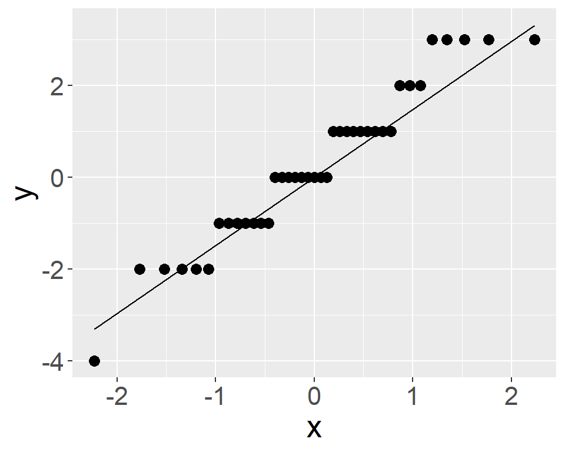

```r
ggplot(mapping = aes(sample = diff_scores)) +
  stat_qq(size = 3) +
  stat_qq_line() +
  theme(text = element_text(size = 20))
```

> It looks strange because there are numerous repetitions of the same value. If you examine the difference scores you will find five -2’s, seven -1’s, nine 0’s and so on. It’s worth considering how you might prevent this issue when designing your own studies.

# Question 28

Repeat question 23 using 20% trimmed means.

- Hint: We never covered a trimmed version of the paired t-test in class; however, we did cover a trimmed version of a one-sample t-test.

```r
library(WRS2)

N <- length(diff_scores)
mu <- 0
G <- 0.2
m <- mean(diff_scores, tr = G)
var <- winvar(diff_scores, tr = G)
s <- sqrt(var)
se <- s / ((1 - 2 * G) * sqrt(N))

# Degrees of Freedom
h <- N - 2 * floor(G * N)
df <- h - 1

# Test Statistic
t <- (m - mu) / se

# p-val
# H0: sexy > nonSexy
# i.e., sexy - nonSexy > 0
p <- pt(t, df = df)

# Confidence interval
alpha <- 0.05
t_crit <- abs(qt(alpha, df = df))

low_ci <- m - Inf * se
top_ci <- m + t_crit * se
```

```
## T = 0.651
```

```
## df = 24
```

```
## p = 0.739
```

```
## [1] "95% CI = (-Inf, 0.7254]"
```

> We fail to reject the null hypothesis that $H_0: Sexy - NotSexy > 0$.